# 2 HarvardX PH526x Using Python for Research

## Week 2: Python Libraries and Concepts Used in Research

### Week 2 introduces you to Python libraries and concepts used in research.

- Learn about Python scope rules
- Learn the basics of scientific and vectorized computing using numpy
- Learn the basics of plotting with matplotlib.pyplot
- Learn the basics of random numbers with the random module
- Learn how to measure time

Part 1 - scope rules and classes  
Part 2 - covers NumPy  
Part 3 - overs Matplotlib and Pyplot  
Part 4 - randomness and time

### Scope Rules

**L** Local  
**E** Enclosing Function  
**G** Global  
**B** Built-in

```python
def update(n, x):
    n = 2
    x.append(4)
    print("update: ", n, x)

def main():
    n = 1
    x = [0,1,2,3]
    print('main: ', n, x)
    update(n, x)
    print('main: ', n, x)
main()
```

```
main:  1 [0, 1, 2, 3]
update:  2 [0, 1, 2, 3, 4]
main:  1 [0, 1, 2, 3, 4]
```

```python
def increment(n):
    n += 1
    print(n)

n = 1
increment(n)
print(n)
```

```
2
1
```

```python
def increment(n):
    n += 1
    return(n)

n = 1
while n < 10:
    n = increment(n)
print(n)
```

```
10
```

### Classes and Object-Oriented Programming

```python
ml = [5,9,3,6,8,11,4,3]
ml.sort()
ml
```

```
[3, 3, 4, 5, 6, 8, 9, 11]
```

```python
min(ml)
```

```
3
```

```python
max(ml)
```

```
11
```

```python
ml.remove(9)
ml
```

```
[3, 3, 4, 5, 6, 8, 11]
```

```python
class MyList(list):     # derived class 'MyList' base class - 'list'
    def remove_min(self):
        self.remove(min(self))
    def remove_max(self):
        self.remove(max(self))
```

```python
x = [10,3,5,1,2,7,6,4,8]
y = MyList(x)
```

```python
dir(x)   # what methods are available (dir)
```

```
['__add__',
 '__class__',
 '__contains__',
 '__delattr__',
 '__delitem__',
 '__dir__',
 '__doc__',
 '__eq__',
 '__format__',
 '__ge__',
 '__getattribute__',
 '__getitem__',
 '__gt__',
 '__hash__',
 '__iadd__',
 '__imul__',
 '__init__',
 '__init_subclass__',
 '__iter__',
 '__le__',
 '__len__',
 '__lt__',
 '__mul__',
 '__ne__',
 '__new__',
 '__reduce__',
 '__reduce_ex__',
 '__repr__',
 '__reversed__',
 '__rmul__',
 '__setattr__',
 '__setitem__',
 '__sizeof__',
 '__str__',
 '__subclasshook__',
 'append',
 'clear',
 'copy',
 'count',
 'extend',
 'index',
 'insert',
 'pop',
 'remove',
 'reverse',
 'sort']
```

```python
dir(y)
```

```
['__add__',
 '__class__',
 '__contains__',
 '__delattr__',
 '__delitem__',
 '__dict__',
 '__dir__',
 '__doc__',
 '__eq__',
 '__format__',
 '__ge__',
 '__getattribute__',
 '__getitem__',
 '__gt__',
 '__hash__',
 '__iadd__',
 '__imul__',
 '__init__',
 '__init_subclass__',
 '__iter__',
 '__le__',
 '__len__',
 '__lt__',
 '__module__',
 '__mul__',
 '__ne__',
 '__new__',
 '__reduce__',
 '__reduce_ex__',
 '__repr__',
 '__reversed__',
 '__rmul__',
 '__setattr__',
 '__setitem__',
 '__sizeof__',
 '__str__',
 '__subclasshook__',
 '__weakref__',
 'append',
 'clear',
 'copy',
 'count',
 'extend',
 'index',
 'insert',
 'pop',
 'remove',
 'remove_max',
 'remove_min',
 'reverse',
 'sort']
```

```python
y.remove_min()
y
```

```
[10, 3, 5, 2, 7, 6, 4, 8]
```

```python
y.remove_max()
y
```

```
[3, 5, 2, 7, 6, 4, 8]
```

```python
class NewList(list):
    def remove_max(self):
        self.remove(max(self))
    def append_sum(self):
        self.append(sum(self))
```

```python
x = NewList([1,2,3])
while max(x) < 10:
    x.remove_max()
    x.append_sum()
```

### Introduction to NumPy Arrays

NumPy is a pythong module designed for scientific computation.  
Numpy arrays are n-dimensional array objects  
Numpy also provides tools for integrating your code with existing C, C and Fortran code. Numpy provides useful tools to help you perform linear algebra, generate random numbers and much much more  
numpy.org  
NumPy arrays are additional data type provided by NumPy and they are used for representing vectors and matrices. NumPy arrays are fixed size unlike python lists  
NumPy arrays are also all of the same data type leading to more efficient and simpler code.

```python
import numpy as np
zero_vector = np.zeros(5)
zero_matrix = np.zeros((5,3))   # 5 rows and 3 columns
zero_vector
```

```
array([ 0.,  0.,  0.,  0.,  0.])
```

```python
zero_matrix
```

```
array([[ 0.,  0.,  0.],
       [ 0.,  0.,  0.],
       [ 0.,  0.,  0.],
       [ 0.,  0.,  0.],
       [ 0.,  0.,  0.]])
```

```python
ones_vector = np.ones(5)
ones_vector
```

```
array([ 1.,  1.,  1.,  1.,  1.])
```

```python
empty_vector = np.empty(5)
empty_vector
```

```
array([ 0.,  0.,  0.,  0.,  0.])
```

```python
x = np.array([1,2,3])
y = np.array([2,4,6])
```

```python
np.array([[1,3],[5,9]])
```

```
array([[1, 3],
       [5, 9]])
```

#### Transpose

first row becomes the first column, second row becomes the second column and so on or  
first column becomes the first row, second column becomes the second row ...

```python
A = np.array([[1,3],[5,9]])
A.transpose()
```

```
array([[1, 5],
       [3, 9]])
```

True or False: a numpy array's length may be edited after being created.  
ANSWER: False

What code will produce the following object?  
numpy.array([0., 0., 0., 0., 0.])  
ANSWER: np.zeros(5)

Consider the following code:  
x = numpy.array([[3,6],[5,7]])  
y = x.transpose()  
print(y) What does this print  
ANSWER: array([[3 5],[6 7]])

### Slicing NumPy Arrays

one-dimension array, indices start at 0  
two-dimensional array, first index is row, second index is column

NumPy arrays can have more dimensions than one of two.  
With multi-dimensional arrays, you can use the colon character in place of a fixed value for an index, which  
means that the array elements corresponding to all values of that particular index will be returned.

```python
import numpy as np
x = np.array([1,2,3])
y = np.array([2,4,6])
X = np.array([[1,2,3],[4,5,6]])
Y = np.array([[2,4,6],[8,10,12]])
```

```python
x[2]   # 3rd element
```

```
3
```

```python
x[0:2]  # first two elements
```

```
array([1, 2])
```

```python
z = x + y   # addees the two arrays (same size)
z
```

```
array([3, 6, 9])
```

```python
X[:,1]    # First Column
```

```
array([2, 5])
```

```python
Y[:,1]
```

```
array([ 4, 10])
```

```python
X[:,1]  + Y[:,1]   # Add first columns
```

```
array([ 6, 15])
```

```python
X[1,:]   # First Row
```

```
array([4, 5, 6])
```

```python
X[1,:] + Y[1,:]   # Add first row
```

```
array([12, 15, 18])
```

```python
X[1]     # Same as X[1,:]
```

```
array([4, 5, 6])
```

```python
# Adding a two list will extend the list not add
[1,2,3] + [4,5,6]
```

```
[1, 2, 3, 4, 5, 6]
```

```python
np.array([1,2,3]) + np.array([4,5,6])
```

```
array([5, 7, 9])
```

x = np.array([1,2,5])  
x[1:2]  
What does this return?  
ANSWER: np.array([2])

a = np.array([1,2])  
b = np.array([3,4,5])  
a + b  
What does this return  
ANSWER: This code contains an error

### Indexing NumPy Arrays

NumPy arrays can also be indexed with other arrays or other sequence like object like lists.

```python
z1 = np.array([1,3,5,7,9])
z2 = z1 + 1
z1
```

```
array([1, 3, 5, 7, 9])
```

```python
z2
```

```
array([ 2,  4,  6,  8, 10])
```

```python
ind = [0,2,3]
```

```python
z1[ind]
```

```
array([1, 5, 7])
```

```python
# take the list and turn into numpy array and still use it
ind = np.array([0,2,3])
```

```python
z1[ind]
```

```
array([1, 5, 7])
```

```python
# boolean arrays
z1 >6
```

```
array([False, False, False,  True,  True], dtype=bool)
```

```python
# we can use the boolean array, also called a logical array , to index another vector
z1[z1 > 6]
```

```
array([7, 9])
```

```python
z2[z1>6]
```

```
array([ 8, 10])
```

```python
ind = z1 > 6
ind
```

```
array([False, False, False,  True,  True], dtype=bool)
```

```python
z1[ind]
```

```
array([7, 9])
```

**Important**  
When you slice an array using the colon operator, you get a view of object. This means that if you modify it,  
The original array will also be modified. This is in contrast with what happens when you index an array.

```python
z1
```

```
array([1, 3, 5, 7, 9])
```

```python
w = z1[0:3]
w
```

```
array([1, 3, 5])
```

```python
w[0] = 3
w
```

```
array([3, 3, 5])
```

```python
z1    # z1 also changed
```

```
array([3, 3, 5, 7, 9])
```

```python
z1 = np.array([1,3,5,7,9])
ind = np.array([0,1,2])
ind
```

```
array([0, 1, 2])
```

```python
w = z1[ind]
w
```

```
array([1, 3, 5])
```

```python
w[0] = 3
w
```

```
array([3, 3, 5])
```

```python
# How ever, z1 is not changed
z1
```

```
array([1, 3, 5, 7, 9])
```

a = np.array([1,2])  
b = np.array([3,4,5])  
b[a]  
What does this return?  
Answer: np.array([4,5])

c = b[1:]  
b[a] is c  
What does this return?  
ANSWER: False

### Building and Examining NumPy Arrays

np.linspace()  
np.logspace  
Check shape and size of an array  
np.any()  
np.all()

```python
# to construct an array of 10 linearly spaced elements starting with 0 and ending with 100
np.linspace(0,100,10)   # 10 is the number of elements
```

```
array([   0.        ,   11.11111111,   22.22222222,   33.33333333,
         44.44444444,   55.55555556,   66.66666667,   77.77777778,
         88.88888889,  100.        ])
```

```python
# to constuct logarithmically spaced elements between 10 and 100
np.logspace(1,2,10)   # log of 10 is 1,  log of 100 is 2, 10 is the number of elements
```

```
array([  10.        ,   12.91549665,   16.68100537,   21.5443469 ,
         27.82559402,   35.93813664,   46.41588834,   59.94842503,
         77.42636827,  100.        ])
```

```python
# to construct an array of ten logarithmically spaced elements between 250, 500
np.logspace(np.log10(250), np.log10(500), 10)
```

```
array([ 250.        ,  270.01493472,  291.63225989,  314.98026247,
        340.19750004,  367.43362307,  396.85026299,  428.62199143,
        462.93735614,  500.        ])
```

```python
X = np.array([[1,2,3],[4,5,6]])
X.shape
```

```
(2, 3)
```

```python
X.size
```

```
6
```

```python
x = np.random.random(10)
```

```python
np.any(x > 0.9)
```

```
True
```

```python
np.all(x >= 0.1)
```

```
True
```

```python
x
```

```
array([ 0.93913526,  0.24053581,  0.80606818,  0.55505454,  0.7681196 ,
        0.742092  ,  0.71943341,  0.84603334,  0.69176625,  0.29780953])
```

x=20  
not np.any([x%i == 0 for i in range(2, x)])  
What does the above code do?  
Finds whether x is prime

## Introduction to Matplotlib and Pyplot

```python
import matplotlib.pyplot as plt
plt.plot([0,1,4,9,16])
```

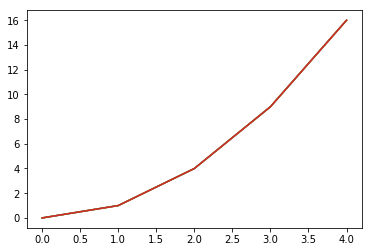

```python
plt.plot([0,1,4,9,16]);
plt.show()
```

```python
x = np.linspace(0,10,20)
y = x**2.0
```

```python
x
```

```
array([  0.        ,   0.52631579,   1.05263158,   1.57894737,
         2.10526316,   2.63157895,   3.15789474,   3.68421053,
         4.21052632,   4.73684211,   5.26315789,   5.78947368,
         6.31578947,   6.84210526,   7.36842105,   7.89473684,
         8.42105263,   8.94736842,   9.47368421,  10.        ])
```

```python
y
```

```
array([   0.        ,    0.27700831,    1.10803324,    2.49307479,
          4.43213296,    6.92520776,    9.97229917,   13.5734072 ,
         17.72853186,   22.43767313,   27.70083102,   33.51800554,
         39.88919668,   46.81440443,   54.29362881,   62.32686981,
         70.91412742,   80.05540166,   89.75069252,  100.        ])
```

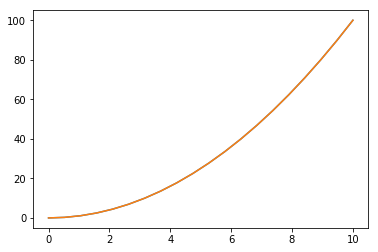

```python
plt.plot(x,y);
plt.show()
```

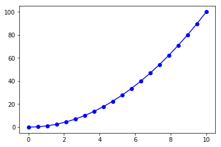

```python
x = np.linspace(0,10,20)
y1 = x**2.0
y2 = x**1.5
plt.plot(x,y1, "bo-")   # blue, circle, solid line
plt.show()
```

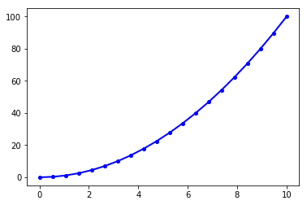

```python
plt.plot(x,y1, "bo-", linewidth=2, markersize=4)   # blue, circle, solid line
plt.show()
```

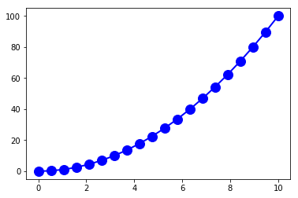

```python
plt.plot(x,y1, "bo-", linewidth=2, markersize=12)   # blue, circle, solid line
plt.show()
```

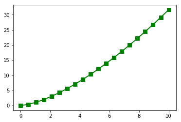

```python
plt.plot(x,y2, "gs-", linewidth=2, markersize=8)  # green, square, solidline
plt.show()
```

What does plt.show() do?  
ANSWER: Show a plot that is already created

What does plt.plot([0,1,2],[0,1,4],"rd-") do?  
ANsWER: A plot of two connected lines, with red diamonds at the junctures.

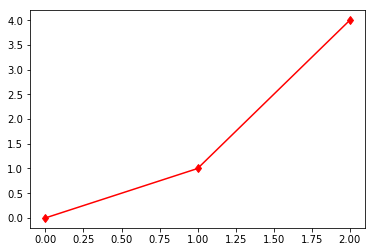

```python
plt.plot([0,1,2],[0,1,4],"rd-")
plt.show()
```

### Customizing your plots

- Add legend : legend()
- Adjust axes : axis()
- Set axis labels: xlabel(), ylabel()
- Save figure : savefig()

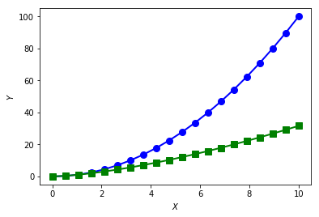

```python
x = np.linspace(0,10,20)
y1 = x**2.0
y2 = x**1.5
plt.plot(x, y1, "bo-", linewidth=2, markersize=8)
plt.plot(x, y2, "gs-", linewidth=2, markersize=8)
plt.xlabel("$X$")  # latex
plt.ylabel("$Y$")  # latex
plt.show()
```

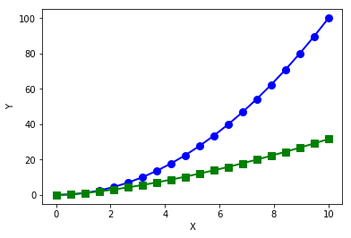

```python
x = np.linspace(0,10,20)
y1 = x**2.0
y2 = x**1.5
plt.plot(x, y1, "bo-", linewidth=2, markersize=8)
plt.plot(x, y2, "gs-", linewidth=2, markersize=8)
plt.xlabel("X")   # note the font
plt.ylabel("Y")   # note the font
plt.show()
```

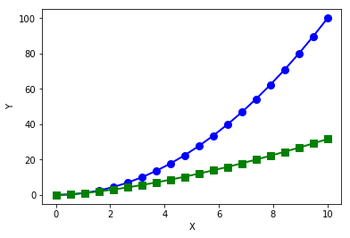

```python
x = np.linspace(0,10,20)
y1 = x**2.0
y2 = x**1.5
plt.plot(x, y1, "bo-", linewidth=2, markersize=8)
plt.plot(x, y2, "gs-", linewidth=2, markersize=8)
plt.xlabel("X")
plt.ylabel("Y")
# plt.axis([xmin, xmax, ymin, ymax])
plt.axis([-0.5, 10.5, -5, 105])
plt.show()
```

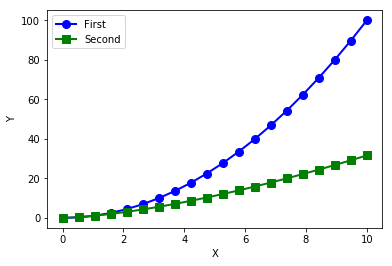

```python
x = np.linspace(0,10,20)
y1 = x**2.0
y2 = x**1.5
plt.plot(x, y1, "bo-", linewidth=2, markersize=8, label="First")
plt.plot(x, y2, "gs-", linewidth=2, markersize=8, label= "Second")
plt.xlabel("X")
plt.ylabel("Y")
# plt.axis([xmin, xmax, ymin, ymax])
plt.axis([-0.5, 10.5, -5, 105])
plt.legend(loc="upper left")
plt.show()
```

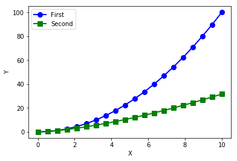

```python
import os
os.chdir('D:/Dev/Python/PythonForResearch/books')
x = np.linspace(0,10,20)
y1 = x**2.0
y2 = x**1.5
plt.plot(x, y1, "bo-", linewidth=2, markersize=8, label="First")
plt.plot(x, y2, "gs-", linewidth=2, markersize=8, label= "Second")
plt.xlabel("X")
plt.ylabel("Y")
# plt.axis([xmin, xmax, ymin, ymax])
plt.axis([-0.5, 10.5, -5, 105])
plt.legend(loc="upper left")
plt.savefig("myplot.pdf")
plt.show()
```

### Plotting using Logarithmic Axes

In some plots, it's helpful to have one or both axes be logarithmic.This means that for any given point to be plotted, its x or y-coordinate,or both, are transformed using the log function. So what ends up being plotted on the x-axes is not the original x-coordinate, but instead the value of log x.

The logarithm is taken by default in base 10. So if, for example, log of 100 is equal to 2, but the base can be specified to be something else as needed.

- semilogx() plots the x-axes on a log scale and the y in the ogirinal scale
- semilogy() plots the y-axes on the log scale and the x in the original scale.
- loglog() plots both x and y on logarithmic scales

To understand why logarithmic plots are sometimes useful,  
consider y = x<sup>α</sup>  
if α is equal to 1, that corresponds to a line that goes through the origin  
if α is equal to 2, gives ua a parabola

log y = log x<sup>α</sup>  
log y = α log x  
y' = α x'  
When we plot this α is the slope of the line

The lesson here is that functions of the form y is equal to x to power α show up as straight lines on a loglog() plot

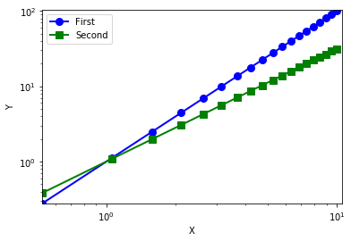

```python
x = np.linspace(0,10,20)
y1 = x**2.0
y2 = x**1.5
plt.loglog(x, y1, "bo-", linewidth=2, markersize=8, label="First")    # loglog()
plt.loglog(x, y2, "gs-", linewidth=2, markersize=8, label= "Second")  # loglog()
plt.xlabel("X")
plt.ylabel("Y")
# plt.axis([xmin, xmax, ymin, ymax])
plt.axis([-0.5, 10.5, -5, 105])
plt.legend(loc="upper left")
plt.savefig("myplot.pdf")
plt.show()
```

if you wanted even spacing on the x-axes, we can generate numbers that are evenly spaced, not on a linear scale which is what we get from np.linspace, but on the logarithmic scale

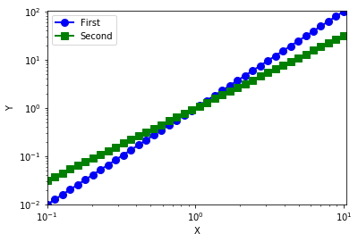

```python
x = np.logspace(-1,1,40)   # -1 means that my first point is 0.1, end at 1 which is 10
y1 = x**2.0
y2 = x**1.5
plt.loglog(x, y1, "bo-", linewidth=2, markersize=8, label="First")    # loglog()
plt.loglog(x, y2, "gs-", linewidth=2, markersize=8, label= "Second")  # loglog()
plt.xlabel("X")
plt.ylabel("Y")
# plt.axis([xmin, xmax, ymin, ymax])
plt.axis([-0.5, 10.5, -5, 105])
plt.legend(loc="upper left")
plt.savefig("myplot.pdf")
plt.show()
```

x=np.logspace(0,1,10)  
y=x**2  
plt.loglog(x,y,"bo-")  
What does this return?  
ANSWER: A logarithmic plot, which looks like a straight line with equal spacing.

### Generating Histograms

- plt.hist()
- plt.subplot()

first generate some random numbers, 1000 samples or draws from the standard normal distribution, which is a special case of the normal distribution that has mean equal to 0 and variance equal to 1

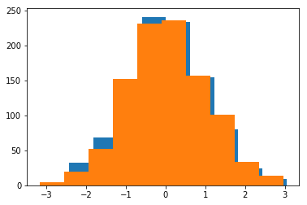

```python
import matplotlib.pyplot as plt
import numpy as np

x = np.random.normal(size = 1000)
plt.hist(x)
plt.show()
```

When we set normed to be true, the histogram, in this case on the y-axis, instead of having the number of observations that fall in each bin, we have the proportion of observations that fall in each bin. That's what it means for a histogram to be normalized.

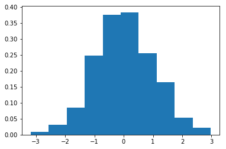

```python
plt.hist(x, normed=True);
plt.show()
```

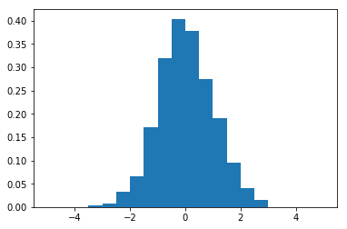

```python
plt.hist(x, normed=True, bins=np.linspace(-5,5,21));
plt.show()
```

If we think about the first example where we just have one bin, to have one bin we need to specify the start point-- the start location of the bin and the end location of that bin. So to get one bin, we need two points. If we had two bins we would need three points, and so on. This is why to have 20 bins, we will need to have 20 plus 1, or 21, points along the x-axis.

Let's then examine another distribution, which is a bit more exotic, the so-called gamma distribution.  
It is a continuous probability density function that starts at 0 and goes all the way to positive infinity.  
The gamma distribution, like the normal distribution, has two parameters.

subplot, several subplots within each figure, it takes three arguments where the first two specify the number of rows and the number of columns in the subplot. The third argument gives the plot number

For example, if you specify two rows and three columns, then you will have six subplots

2x3

| 1 | 2 | 3 |
| --- | --- | --- |
| 4 | 5 | 6 |

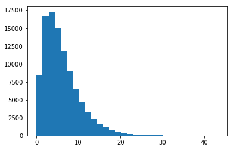

```python
x = np.random.gamma(2,3, 100000)
plt.hist(x, bins=30)
plt.show()
```

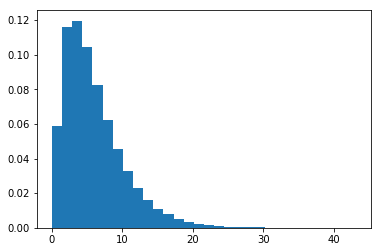

```python
plt.hist(x, bins=30, normed=True)
plt.show()
```

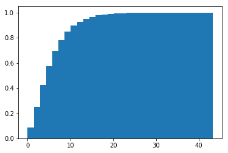

```python
plt.hist(x, bins=30, normed=True, cumulative=True)
plt.show()
```

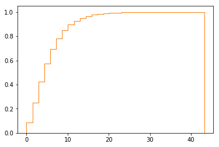

```python
plt.hist(x, bins=30, normed=True, cumulative=True, histtype="step")
plt.show()
```

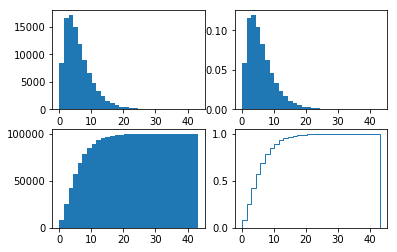

```python
plt.figure()
plt.subplot(221)
plt.hist(x, bins=30)
plt.subplot(222)
plt.hist(x, bins=30, normed=True)
plt.subplot(223)
plt.hist(x, bins=30, cumulative=30)
plt.subplot(224)
plt.hist(x, bins=30, normed=True, cumulative=True, histtype="step")
plt.show()
```

Which will have wider bins, np.linspace(-5,5,21) or np.linspace(-5,5,201)?  
ANSWER: np.linspace(-5,5,21)

What will plt.subplot(333) do?  
ANSWER : Create a smaller subplot in the topright of the figure.

Will plt.subplot(3, 3, 3) create a different plot from plt.subplot(333)?  
ANSWER: No

### Simulating Randomness

- random.choice

Many processes in nature involve randomness in one form or another. Whether we investigate the motions of microscopic molecules or study the popularity of electoral candidates, we see randomness, or at least apparent randomness, almost everywhere.  
In addition to phenomena that are genuinely random, we often use randomness when modeling complicated systems  
to abstract away those aspects of the phenomenon for which we do not have useful simple models.In other words, we try to model those parts of a process that we can explain in relatively simple terms, and we assume, true or not, that the rest is noise.

```python
# simplest random procss - the flip of a single coin
import random
random.choice(['H','T'])
```

```
'T'
```

```python
random.choice([0,1])
```

```
1
```

```python
random.choice([1,2,3,4,5,6])
```

```
6
```

```python
random.choice(range(1,7))
```

```
2
```

Imagine a situation where you have three dice, one of them having six faces, one of them having eight faces, and one of them having ten faces. How could you simulate one outcome for a process, where one of these dice, chosen uniformly at random, is rolled just one time?

```python
random.choice([range(1,7), range(1,9), range(1,11)])
```

```
range(1, 11)
```

```python
random.choice(random.choice([range(1,7), range(1,9), range(1,11)]))
```

```
5
```

Use random.choice and range to generate a random integer from 0-9. Answer: random.choice(range(0,10))

What will random.choice(list([1,2,3,4])) produce?  
ANSWER: A value from 1-4, selected at random.

Which of the following lines of code sums random integers from 0-9?  
sum(random.choice(range(10)) for i in range(10))

```python
random.choice(list([1,2,3,4]))
```

```
3
```

```python
sum(random.choice(range(10)) for i in range(10))
```

```
41
```

### Examples Involving Randomness

- simulations
- visualization roll a die 100 times and plot a histogram of the outcomes, meaning a histogram that shows how frequent the numbers from 1 to 6

```python
import random
random.choice([1,2,3,4,5,6])
rolls = []
for k in range(100):
    rolls.append(random.choice([1,2,3,4,5,6]))
```

```python
len(rolls)
```

```
100
```

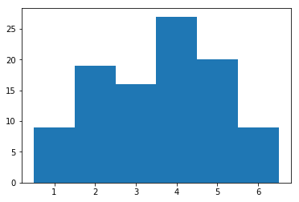

```python
plt.hist(rolls, bins=np.linspace(0.5,6.5,7))
plt.show()
```

```python
for k in range(10000):
    rolls.append(random.choice([1,2,3,4,5,6]))
```

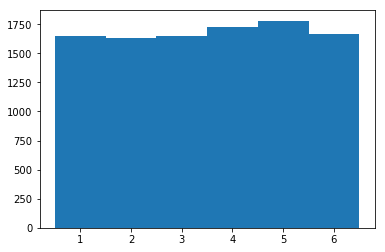

```python
plt.hist(rolls, bins=np.linspace(0.5,6.5,7))
plt.show()
```

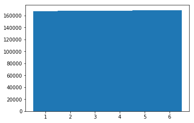

```python
for k in range(1000000):
    rolls.append(random.choice([1,2,3,4,5,6]))
plt.hist(rolls, bins=np.linspace(0.5,6.5,7))
plt.show()
```

we learned how to simulate a die, how to throw a die any number of times, how to visualize the output as a histogram, and by evoking the law of large numbers, we have an understanding of what should happen, which in this case was confirmed by our simulation.

```python
Ys = []
for rep in range(100):
    y = 0
    for k in range(10):
        x = random.choice([1,2,3,4,5,6])
        y = y + x
    Ys.append(y)
```

```python
len(Ys)
```

```
100
```

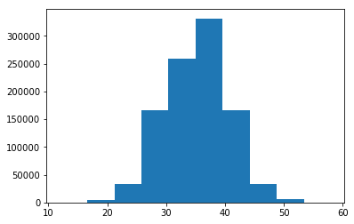

```python
Ys = []
for rep in range(1000000):
    y = 0
    for k in range(10):
        x = random.choice([1,2,3,4,5,6])
        y = y + x
    Ys.append(y)
plt.hist(Ys)
plt.show()
```

central limit theorem (CLT) states that the sum of a large number of random varaibles regardless of their distribution will approximately follow a normal distribution.

What will random.choice(list((1,2,3,4))) do?  
ANSWER: Sample from the list [1,2,3,4]

What is the law of large numbers with respect to histograms?  
ANSWER: We expect the histogram of a sample to better reflect the distribution as the sample size increases.

What is the Central Limit Theorem?  
ANSWER: The distribution of the sum of many random variables is approximately normal.

### Using the NumPy Random Module

NumPy makes it possible to generate all kinds of random variables.  
Let's start with generating numbers from the standard uniform distribution,which is a the completely flat distribution between 0 and 1 such that any floating point number between these two endpoints is equally likely.

```python
import numpy as np
np.random.random()
```

```
0.13504892669314184
```

to generate a 1d array of numbers

```python
np.random.random(5)
```

```
array([ 0.6807036 ,  0.93115518,  0.85008753,  0.77178556,  0.93045103])
```

to generate 2d array of random numbers, insert a tubple and first argument is the number of rows

```python
np.random.random((5,3))
```

```
array([[ 0.57774911,  0.37124627,  0.62950941],
       [ 0.53292792,  0.96931607,  0.32736634],
       [ 0.46609534,  0.02012832,  0.37455225],
       [ 0.54284642,  0.68158249,  0.75752611],
       [ 0.87550252,  0.8939069 ,  0.30184888]])
```

normal distribution, it requires a mean and the standard deviation as its input parameters  
in this case mean = 0 sd = 1, this gives us the so-called standard normal distribution  
Third argument is the length of array

```python
np.random.normal(0, 1)
```

```
1.386748268338058
```

```python
np.random.normal(0, 1, 5)
```

```
array([ 0.47541614,  0.79503206,  1.19742413, -0.68596235,  1.23204436])
```

```python
np.random.normal(0,1,(2,5))    # 2D array with 2 rows and 5 columns (indicated within tuple)
```

```
array([[-0.69715134,  0.7075676 , -0.53686684, -0.88228145, -0.76390593],
       [ 0.14155095, -1.16864598,  0.14413726, -2.44849405, -1.41053223]])
```

Let's revisit our example where we roll 10 die and added the result together.

Remember, we defined a random variable y as the sum of random variables x1 through x10, where each x variable is a standard die with 6 faces with the numbers from 1 to 6 on them.

We can code this example using NumPy arrays. My overall strategy is to generate a table  
where each element corresponds to a roll of a die such that each element is a number between 1 and 6.  
If I have 10 columns in my table, I can then create my variable y by summing the table over all columns.

Finally, the number of rows in the table is going to be equal to the number of realizations of the variable y that I would like to generate.

|  | X<sub>1</sub> | X<sub>2</sub> | .... | X<sub>10</sub> |
| --- | --- | --- | --- | --- |
| Y<sub>1</sub> |  |  |  |  |
| Y<sub>2</sub> |  |  |  |  |

Google "How to generate random integers in numpy"  
[numpy, random.randint](https://docs.scipy.org/doc/numpy-1.13.0/reference/generated/numpy.random.randint.html)

if you look at the help pabe, for input arguments, we have to provide at least one argument but we can potentially provide up to three different arguments.

```python
np.random.randint(1,7)
```

```
4
```

```python
X = np.random.randint(1,7,(10,3))   # 10 rows and 3 columns
X
```

```
array([[3, 6, 6],
       [5, 5, 5],
       [6, 4, 1],
       [6, 5, 5],
       [4, 2, 2],
       [1, 4, 1],
       [6, 1, 2],
       [1, 3, 6],
       [6, 1, 4],
       [6, 3, 4]])
```

```python
X.shape
```

```
(10, 3)
```

The next step is, how to use the sum.  
By using IPython help

```python
help(np.sum)
```

```
Help on function sum in module numpy.core.fromnumeric:

sum(a, axis=None, dtype=None, out=None, keepdims=<class 'numpy._globals._NoValue'>)
    Sum of array elements over a given axis.

    Parameters
    ----------
    a : array_like
        Elements to sum.
    axis : None or int or tuple of ints, optional
        Axis or axes along which a sum is performed.  The default,
        axis=None, will sum all of the elements of the input array.  If
        axis is negative it counts from the last to the first axis.

        .. versionadded:: 1.7.0

        If axis is a tuple of ints, a sum is performed on all of the axes
        specified in the tuple instead of a single axis or all the axes as
        before.
    dtype : dtype, optional
        The type of the returned array and of the accumulator in which the
        elements are summed.  The dtype of `a` is used by default unless `a`
        has an integer dtype of less precision than the default platform
        integer.  In that case, if `a` is signed then the platform integer
        is used while if `a` is unsigned then an unsigned integer of the
        same precision as the platform integer is used.
    out : ndarray, optional
        Alternative output array in which to place the result. It must have
        the same shape as the expected output, but the type of the output
        values will be cast if necessary.
    keepdims : bool, optional
        If this is set to True, the axes which are reduced are left
        in the result as dimensions with size one. With this option,
        the result will broadcast correctly against the input array.

        If the default value is passed, then `keepdims` will not be
        passed through to the `sum` method of sub-classes of
        `ndarray`, however any non-default value will be.  If the
        sub-classes `sum` method does not implement `keepdims` any
        exceptions will be raised.
```

[output cut: 31 more lines]

```
    >>> np.sum([0.5, 1.5])
    2.0
    >>> np.sum([0.5, 0.7, 0.2, 1.5], dtype=np.int32)
    1
    >>> np.sum([[0, 1], [0, 5]])
    6
    >>> np.sum([[0, 1], [0, 5]], axis=0)
    array([0, 6])
    >>> np.sum([[0, 1], [0, 5]], axis=1)
    array([1, 5])

    If the accumulator is too small, overflow occurs:

    >>> np.ones(128, dtype=np.int8).sum(dtype=np.int8)
    -128
```

```python
np.sum(X)  # sum of all of the elements in the array
```

```
114
```

```python
np.sum(X, axis=0)  # sum of rows
```

```
array([44, 34, 36])
```

```python
np.sum(X, axis=1) # sum of columns
```

```
array([15, 15, 11, 16,  8,  6,  9, 10, 11, 13])
```

```python
# np.sum(X, axis=3 )   This is for 3d array
```

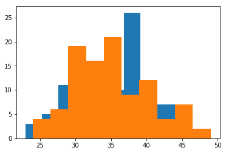

```python
X = np.random.randint(1,7,(100,10))
Y = np.sum(X, axis=1)
plt.hist(Y)
plt.show()
```

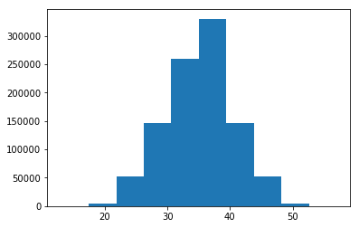

```python
X = np.random.randint(1,7,(1000000,10))
Y = np.sum(X, axis=1)
plt.hist(Y)
plt.show()
```

What does numpy.random.random((5,2,3)) do?  
ANSWER: Generate a 5 x 2 x 3 NumPy array with random uniform values.

What does numpy.random.normal(1,2,3) do?  
ANSWER: Generate 3 samples with mean 1 and standard deviation 2

What does numpy.random.randint(1,5,(2,3)) do?  
ANSWER: Generate a 2 x 3 array with random integers from 1-4

What is the dimension of numpy.sum(numpy.random.randint(1,7,(100,10)), axis=0)?  
ANSWER: 10

```python
 np.sum(np.random.randint(1,7,(100,10)), axis=0)
```

```
array([344, 345, 345, 333, 324, 356, 357, 347, 363, 347])
```